# Rowley_HLM2_Final

Brock Rowley

6/8/2021

# Introduction:

Student substance misuse is an ongoing problem in schools across the United States, and it is outside the training and expertise of most educators. Nonetheless, school staff are presented with situations in which students bring substances to campus or arrive under the influence of them. Despite the evidence that zero-tolerance policies do not improve school safety nor student behavior (American Psychological Association, 2008), the likely default response in contemporary schools to substance-related behavior occurs through their discipline systems. Although the national mindset is moving toward a more inclusive approach to behavioral health, this study seeks to determine to what extent school practices have shifted with it. Specifically, this study seeks to examine how use of out-of-school suspension (OSS) differs by substance possessed and student race/ethnicity.

# Research Questions:

1. To what extent does the substance a student possessed for their referral (Alcohol, Tobacco, or Drugs) predict whether or not they receive an out of school suspension for substance possession?
2. To what extent does student race predict whether or not a student receives an out of school suspension for substance possession?
3. To what extent is there an interaction between student race and substance in predicting out of school suspension for substance possession?

# Method:

# Procedure:

Analysis was done using only the first referrals for substance possession for each student in the dataset to eliminate concerns about possible confounding of analyses related to decision-making with subsequent referrals. Prior to beginning this course, the following steps were taken to prepare the data set for analysis: (a) the dataset was restricted to contain only the 2018-19 school year, (b) variables were created including a dummy coded variable for use of suspension and expulsion for each referral and a dummy coded variable for type of substance possessed for each referral, (c) the dataset was pivoted the dataset wider by student so that referrals, in order of date of receipt, were nested with students, (e) the sample was further restricted to grades 6-12 and (f) the dataset was restricted only variables of interest. For analysis in R, the variables needed to be properly formatted as factors to use multilevel modeling. Missing data was handled by listwise deletion for instances where an individual student’s race or ethnicity was not available (i.e., listed as Not Applicable, NA). The race or ethnicity identifier was drawn from the National Center on Educational Statistics approach for collecting and disseminating extant data. In this case, 7.7% (2360 of 30773 observations) of the data was removed from analyses because there was insufficient demographic information.

# Measures:

## Dependent Variable

# Analytic Plan:

**Table 1**

Number of Office Refferals by Race and Substance Type

| RaceEthnicity | Alcohol | Drugs | Tobacco |
| --- | --- | --- | --- |
| 1 | 65 | 268 | 254 |
| 2 | 32 | 156 | 214 |
| 3 | 888 | 4004 | 2421 |
| 4 | 224 | 1506 | 1390 |
| 5 | 950 | 3564 | 11354 |
| 8 | 6 | 56 | 64 |
| 44 | 68 | 338 | 591 |
| NA | 167 | 569 | 1624 |

Note. 1 = Native, 2 = Asian, 3 = Latinx, 4 = Black, 5 = White, 8 = Pacific_Islander, 44 = Multi.

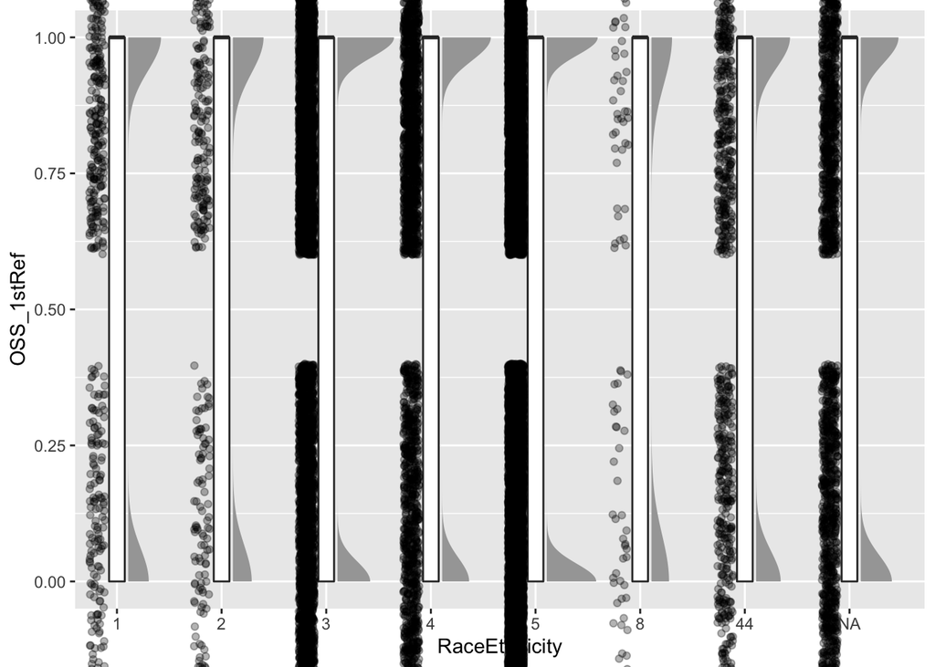

Descriptive analysis indicates some differences in likelihood of receiving OSS based on substance type and student race/ethnicity; however, the crosstab table shows that there are different possession trends by student race/ethnicity. For all research questions, modeling accounted for variance at the individual student and school levels. Modeling with nesting at the district level was considered as well, but over 64% of districts had only one school in the data set and 85% of districts had two or fewer schools, meaning interpretation of this variance at the district-level would have limited usefulness if analyzed with a three-level model.

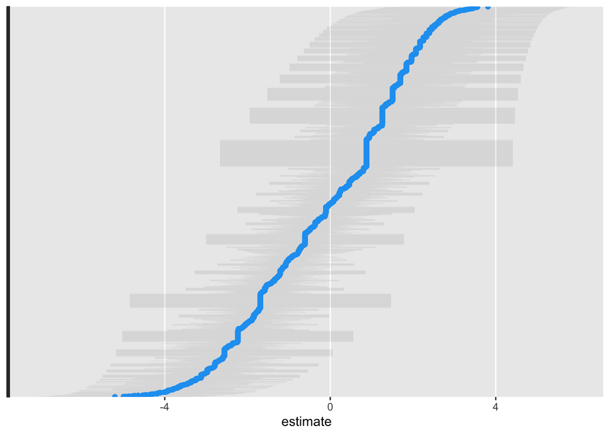

```r
ggplot(tidy_uncond, aes(estimate, level)) +
  geom_linerange(aes(xmin = conf.low, xmax = conf.high),
                 alpha = 0.01) +
  geom_point(color = "#1DA1F2") +
  # get rid of some plot elements
  theme(axis.text.y = element_blank(),
        axis.title.y = element_blank(),
        panel.grid.major.y = element_blank(),
        panel.grid.minor = element_blank())
```

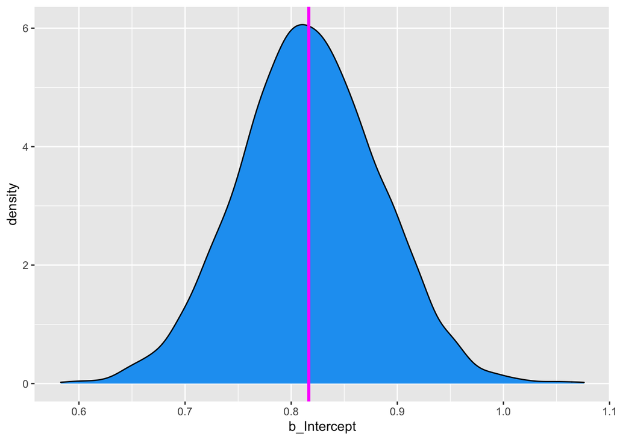

```r
ggplot(m0_posterior, aes(b_Intercept)) +
  geom_density(fill = "#1DA1F2") +
  geom_vline(aes(xintercept = mean(b_Intercept)),
             color = "magenta",
             size = 1.2)
```

# Research Question One:

Analyze use of OSS by substance, logistic multi-level modeling was used examine differential odds ratios while accounting for variance in decisions attributable to nesting at the school-level. Substance type variables were modeled with fixed effects, while variance at the school-level was allowed to vary as a random effect.
$$\begin{aligned}
\operatorname{OSS\_1stRef}_{i} &\sim \operatorname{Binomial}(n = 1, \operatorname{prob}_{\operatorname{OSS\_1stRef} = 1} = \widehat{P}) \\
\log\left[\frac{\hat{P}}{1 - \hat{P}} \right] &=\alpha_{j[i]} + \beta_{1}(\operatorname{Alcohol.1}_{\operatorname{1}}) + \beta_{2}(\operatorname{Drugs.1}_{\operatorname{1}}) \\
\alpha_{j} &\sim N \left(\mu_{\alpha_{j}}, \sigma^2_{\alpha_{j}} \right)
\text{, for School j = 1,} \dots \text{,J}
\end{aligned}$$

```r
exp(fixef(sub))
```

```
## (Intercept)  Alcohol.11    Drugs.11
##   0.8529654  12.2454255  13.4466554
```

```r
posterior_sub <- insight::get_parameters(sub)
posterior_sub
```

```
##     Parameter   Estimate
## 1 (Intercept) -0.1590363
## 2  Alcohol.11  2.5051524
## 3    Drugs.11  2.5987304
```

```r
# translate to probability:
brms::inv_logit_scaled(fixef(sub))
```

```
## (Intercept)  Alcohol.11    Drugs.11
##   0.4603245   0.9245022   0.9307798
```

# Results:

# Discussion:

Sample data is from schools implementing PBIS. Average in schools that do not implement PBIS may be different. It may be appropriate to include other parameters in models. Only includes out-of-school suspension, and does not include other forms of exclusion. Nesting at the district-level would provide answers to questions about how factors at that level (district culture and policies) influence use of suspension, but with the present data, nesting at this level would not have provided those answers. The absence of all substances in a referral (i.e., the intercept) is impossible because the data set contains only referrals for substance possession.

# References:

American Psychological Association. (2008). Are zero tolerance policies effective in the schools? An evidentiary review and recommendations. American Psychologist, 63, 852-862.

Anyon, Y., Jenson, J. M., Altschul, I., Farrar, J., McQueen, J., Greer, E., Downing, B., & Simmons, J. (2014). The persistent effect of race and the promise of alternatives to suspension in school discipline outcomes. Children and Youth Services Review, 44, 379-386.

Skiba, R. J., Chung, C., Trachok, M., Baker, T. L., Sheya, A., & Hughes, R. L. (2014, August 1, 2014). Parsing disciplinary disproportionality: Contributions of infraction, student, and school characteristics to out-of-school suspension and expulsion. American Educational Research Journal, 51, 640-670. https://doi.org/10.3102/0002831214541670